# METHODS for ‘same data different analysts’ project, ‘Many EcoEvo Analysts’ dataset

Luke J. Eberhart-Phillips and Martin Bulla

2020-09-03 16:24:08

# General background

Upon reading the data description and metadata for ‘Many EcoEvo Analysts’ dataset provided by the [project coordinators of ‘same data different analysts’ project](https://osf.io/34fzc/) we have [**A PRIORI** decided upon the procedures and analyses](https://raw.githack.com/MartinBulla/many_analysts/master/MS/Protocol.html) to answer the key **question**: **“To what extent is the growth of nestling blue tits (*Cyanistes caeruleus*) influenced by competition with siblings?”**.

We have anticipated, but not expected, that the actual data differ from the [data description](https://osf.io/34fzc/). Although the nests with reduced and increased brood size are well matched by hatch date (Figure 1, Table 1), in 20% they differ by more than one chick in hatched brood size and in 9% of case the differences are extreme (i.e., brood size differences of 3 or more chicks).

Importantly, the data description indicated that in broods with 4-5 chicks only one chick was taken or added and in broods with 12-16 chicks four chicks were taken or added. This is not the case. Broods of different than indicated size were used and other chick numbers were added and taken (Figure 2). Also, we have not expected that a key variable number of chicks at the start of experiment (‘rear_Cs_at_start_of_rearing’) will be missing 90% of the cases. Thus, we do not use this variable in chick size models (see below).

See [here](https://raw.githack.com/MartinBulla/many_analysts/master/Output/data_exploration_and_analytical_decisions.html) for our entire data exploration work flow that stems from our *a priori* desicions outlined in our [protocol](https://raw.githack.com/MartinBulla/many_analysts/master/MS/Protocol.html).

Code to load tools and prepare data:

```r
# R packages
library(tidyverse)
library(lme4)
library(standardize)
library(kableExtra)
library(ggpubr)
library(here)
library(effects)
library(performance)
library(GGally)

# custom ggplot theme
luke_theme <-
  theme_bw() +
  theme(
    #text = element_text(family = "Franklin Gothic Book"),
    legend.title = element_text(size = 10),
    legend.text = element_text(size = 8),
    axis.title.x = element_text(size = 10),
    axis.text.x  = element_text(size = 8),
    axis.title.y = element_text(size = 10),
    axis.text.y = element_text(size = 8),
    panel.grid.major = element_blank(),
    panel.grid.minor = element_blank(),
    axis.ticks = element_line(size = 0.5, colour = "grey40"),
    axis.ticks.length = unit(0.2, "cm"),
    panel.border = element_rect(linetype = "solid", colour = "grey")
  )

# set the ggplotting theme
theme_set(luke_theme)

BT_data <- read.csv(here("Data/blue_tit_data.csv"), stringsAsFactors = FALSE)

BT_data_tidy <-
  BT_data %>%
  # select variables of interest
  select(chick_ring_number, hatch_year, hatch_nest_breed_ID, rear_nest_breed_ID, rear_area, hatch_mom_Ring,
         genetic_dad_ring_.WP_or_EP., hatch_nest_OH, rear_nest_OH, d0_hatch_nest_brood_size, rear_d0_rear_nest_brood_size,
         rear_nest_trt, net_rearing_manipulation, rear_Cs_at_start_of_rearing, d14_rear_nest_brood_size,
         day_14_tarsus_length, day_14_weight, day14_measurer, chick_sex_molec, number_chicks_fledged_from_rear_nest) %>%
  # rename the genetic dad vaiable
  rename(genetic_dad_ring = genetic_dad_ring_.WP_or_EP.,
         d0_rear_nest_brood_size = rear_d0_rear_nest_brood_size) %>%
  # replace all "." with NA in factor variables
  mutate(chick_sex_molec = as.factor(ifelse(chick_sex_molec == ".", NA,
                                ifelse(chick_sex_molec == "1", "Female", "Male"))),
         chick_BMI = day_14_weight/(day_14_tarsus_length^2)) %>%
  mutate_at(c("hatch_year", "hatch_nest_breed_ID", "rear_nest_breed_ID",
              "day14_measurer", "rear_nest_trt", "hatch_mom_Ring",
              "genetic_dad_ring", "chick_ring_number", "rear_area"),
            as.factor) %>%
  mutate_if(is.factor, list(~na_if(., "."))) %>%
  mutate_at(c("net_rearing_manipulation", "rear_Cs_at_start_of_rearing", "d0_hatch_nest_brood_size",
              "d0_rear_nest_brood_size", "number_chicks_fledged_from_rear_nest"),
            as.numeric) %>%
  # re-name the treatment groups
  mutate(rear_nest_trt =
           as.factor(ifelse(rear_nest_trt == "5", "increase",
                        ifelse(rear_nest_trt == "6", "decrease", "control")))) %>%
  mutate(prop_change_in_brood_size = net_rearing_manipulation/d0_hatch_nest_brood_size)

BT_nest_pairs <-
  BT_data_tidy %>%
  group_by(chick_ring_number) %>%
  mutate_at(c("hatch_nest_breed_ID", "rear_nest_breed_ID"), as.character) %>%
  mutate_at(c("hatch_nest_breed_ID", "rear_nest_breed_ID"), as.numeric) %>%
  dplyr::summarise(pair_ID_min = min(hatch_nest_breed_ID, rear_nest_breed_ID),
            pair_ID_max = max(hatch_nest_breed_ID, rear_nest_breed_ID)) %>%
  left_join(BT_data_tidy, ., by = "chick_ring_number") %>%
  select(hatch_nest_breed_ID, rear_nest_breed_ID, d0_hatch_nest_brood_size,
         d0_rear_nest_brood_size, rear_nest_trt, net_rearing_manipulation,
         rear_Cs_at_start_of_rearing, pair_ID_min, pair_ID_max) %>%
  distinct() %>%
  filter(pair_ID_min != pair_ID_max) %>%
  mutate(pair_ID = paste(pair_ID_min, pair_ID_max, sep = "_")) %>%
  select(hatch_nest_breed_ID, pair_ID)

BT_data_tidy <-
  BT_data_tidy %>%
  left_join(., BT_nest_pairs, by = "hatch_nest_breed_ID")
```

#### Figure 1. Frequency distribution of brood size (left) and hatch date differences (right) in paired nests.

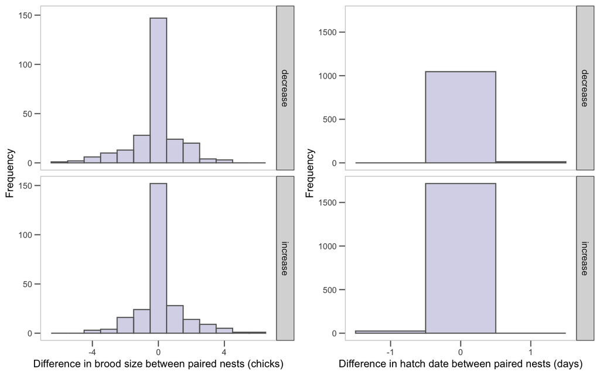

```r
fig_1a <-
  BT_data_tidy %>%
  dplyr::select(pair_ID, d0_hatch_nest_brood_size, d0_rear_nest_brood_size, rear_nest_trt) %>%
  distinct() %>%
  # calculate differences in brood size between hatch and rear nests
  mutate(diff_brood_size = d0_hatch_nest_brood_size - d0_rear_nest_brood_size) %>%
  filter(rear_nest_trt != "control") %>%
  ggplot() +
  geom_histogram(aes(diff_brood_size), alpha = 0.3, color = "grey40", fill = "#7570B3",
                 binwidth = 1, position = "identity") +
  xlab("Difference in brood size between paired nests (chicks)") +
  ylab("Frequency") +
  facet_grid(rear_nest_trt ~ .)

figure_1b <-
  BT_data_tidy %>%
  mutate(date_matching = hatch_nest_OH - rear_nest_OH) %>%
  filter(rear_nest_trt != "control") %>%
  ggplot() +
  geom_histogram(aes(date_matching), alpha = 0.3, color = "grey40", fill = "#7570B3",
                 binwidth = 1, position = "identity") +
  xlab("Difference in hatch date between paired nests (days)") +
  ylab("Frequency") +
  facet_grid(rear_nest_trt ~ .)

ggarrange(fig_1a,
          figure_1b,
          nrow = 1, ncol = 2,
          widths = c(.5, .5))
```

#### Table 1. Frequency distribution of brood size differences in paired nests

```r
BT_data_tidy %>%
  select(pair_ID, d0_hatch_nest_brood_size, d0_rear_nest_brood_size, rear_nest_trt) %>%
  filter(rear_nest_trt != "control") %>%
  distinct() %>%
  # calculate differences in brood size between hatch and rear nests
  mutate(paired_nest_diff_brood_size = d0_hatch_nest_brood_size - d0_rear_nest_brood_size) %>%
  mutate(paired_nest_diff_brood_size_category = ifelse(abs(paired_nest_diff_brood_size) == 0, "0",
                                                       ifelse(abs(paired_nest_diff_brood_size) == 1, "1",
                                                              ifelse(abs(paired_nest_diff_brood_size) == 2, "2", "3 or more")))) %>%
  count(paired_nest_diff_brood_size_category) %>%
  mutate(prop = round(prop.table(n), 3) * 100) %>%
  collect() %>%
  kable(col.names = c("Difference in brood size between paired nests (chicks)",
                      "Frequency of cases", "Percentage (%)")) %>%
  kable_styling(position = "center") %>%
  scroll_box(width = "60%")
```

| Difference in brood size between paired nests (chicks) | Frequency of cases | Percentage (%) |
| --- | --- | --- |
| 0 | 299 | 55.7 |
| 1 | 104 | 19.4 |
| 2 | 63 | 11.7 |
| 3 or more | 49 | 9.1 |
| NA | 22 | 4.1 |

#### Figure 2. Number of chicks moved in relation to original brood size.

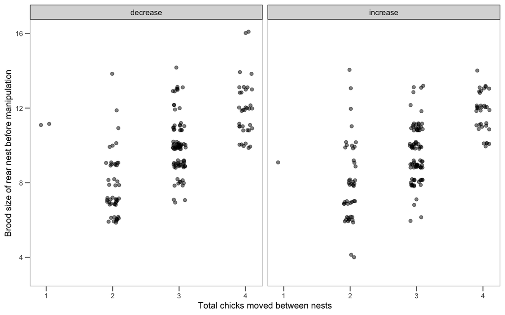

```r
BT_data_tidy %>%
  select(pair_ID, net_rearing_manipulation, d0_rear_nest_brood_size, rear_nest_trt) %>%
  filter(rear_nest_trt != "control") %>%
  distinct() %>%
  ggplot() +
  geom_jitter(aes(x = abs(net_rearing_manipulation), y = d0_rear_nest_brood_size),
              alpha = 0.5, width = 0.1, height = 0.2) +
  xlab("Total chicks moved between nests") +
  ylab("Brood size of rear nest before manipulation") +
  facet_grid(. ~ rear_nest_trt)
```

# Model specification

We have two main sets of the models, as specified in our [a priori protocol](https://raw.githack.com/MartinBulla/many_analysts/master/MS/Protocol.html) and additional exploratory models as a part of extended material.

## (1) Chick mortality model

We specified the change in chick number in the rearing nests (`change_chick_n`) as a difference between the number of chicks at the start of the experiment (`rear_Cs_at_start_of_rearing`) and number of chicks on day 14 of the experiment (`d14_rear_nest_brood_size`) and fitted this variable as a response. The number of chicks to enlarge or reduce the brood (`net_rearing_manipulation`; range -4 to 4, median 0; note that zero indicates the control nests) and brood sex ratio (`brood_sex_ratio`; range 0-1, median 0.5) as explanatory variables. Brood sex ratio was calculated as proportion of males in the nest (1 = all males, 0 = all females), while indicating unknown sex of chicks as 0.5. To control for pseudoreplication (multiple-sampling), we specified the measurer (`day14_measurer`), the compartment of the study area (`rear_area`), the year (`hatch_year`) and the day on which the rear nest hatched left centered within year, i.e. minimum hatch day within each year subtracted from hatch day of a given nest (`rear_nest_OH_l`) as random intercepts. In total, we had 357 nests for which these data were available.

#### Model M - chick mortality

```
    lmer(change_chick_n ~
         net_rearing_manipulation  +
         brood_sex_ratio +
         (1|day14_measurer) +
         (1|rear_area) +
         (1|rear_nest_OH_l) +
         (1|hatch_year),
         REML = TRUE
         )
```

## (2) Chick size models

The dataset contained a chick morphometrics measurements from only one time point (i.e., day 14): tarsus length (`day_14_tarsus_length`) and body mass (`day_14_weight`). Thus, we could not have estimated the actual growth rate given the treatment. We thus infer the growth differences based on treatment only. In addition to tarsus length and body mass, we calculated a composite variable of body mass index (`body_mass_index`):

$$day\_14\_body\_mass\_index = day\_14\_weight / (day\_14\_tarsus\_length^2)$$

In humans, the body mass index broadly categorizes a person as underweight, normal weight, overweight, or obese based on tissue mass (muscle, fat, and bone) and height (structural size). In our case we use tarsus instead of height and we then derive a value that shall classify a given chick as underweight for its tarsus size (e.g., maybe due to intense sibling competition), normal, or overweight (e.g., maybe due to relaxed sibling competition).

We then specified three subsets of models, each with one of the chick morphometric variables as a response. The number of chicks to enlarge or reduce the brood (`net_rearing_manipulation`; range -4 - 4, median 0; note that zero indicates the control nests) was specified as an explanatory variable, testing for the treatment effect. We controlled the model for chick sex (`chick_sex_molec`; m - male, f - female, u - unknown), and brood sex ratio (`brood_sex_ratio`; range 0-1, median 0.5, calculated as described in Chick mortality model) because female and male blue tit chicks grow differently (Mainwaring, Dickens, and Hartley 2010). To control for pseudoreplication (multiple-sampling), we specified the measurer (`day14_measurer`), the compartment of the study area (`rear_area`), the year (`hatch_year`), the day on which the rear nest hatched (left centered) within year (`rear_nest_OH_l`; calculated as described in Chick mortality model), the identification of rearing nest (`rear_nest_breed_ID`) and of genetic parents (`hatch_mom_Ring` and `genetic_dad`) as random intercepts. Such data were available for 2550 nests.

#### Model Ta - tarsus

```
    lmer(day_14_tarsus_length ~
         net_rearing_manipulation + chick_sex_molec +
         brood_sex_ratio +
         (1|day14_measurer) +
         (1|rear_area) +
         (1|rear_nest_OH_l) +
         (1|hatch_year)  +
         (1|rear_nest_breed_ID) +
         (1|hatch_mom_Ring) +
         (1|genetic_dad),
         REML = TRUE
         )
```

#### Model Wa - weight

```
    lmer(day_14_weight ~
         net_rearing_manipulation + chick_sex_molec +
         brood_sex_ratio +
         (1|day14_measurer) +
         (1|rear_area) +
         (1|rear_nest_OH_l) +
         (1|hatch_year)  +
         (1|rear_nest_breed_ID) +
         (1|hatch_mom_Ring) +
         (1|genetic_dad),
         REML = TRUE
         )
```

#### Model Ba - body mass index

```
    lmer(body_mass_index
         net_rearing_manipulation + chick_sex_molec +
         brood_sex_ratio +
         (1|day14_measurer) +
         (1|rear_area) +
         (1|rear_nest_OH_l) +
         (1|hatch_year)  +
         (1|rear_nest_breed_ID) +
         (1|hatch_mom_Ring) +
         (1|genetic_dad),
         REML = TRUE
         )
```

Note that the above described models (Ta, Wa, Ba) differ from those proposed in out [a priori protocol](https://raw.githack.com/MartinBulla/many_analysts/master/MS/Protocol.html) because we followed our a priori decisions about analyses. There were not enough data for the number of chicks at the start of the experiment (`rear_Cs_at_start_of_rearing`) and hence we have not used it in the models. The correlation between `net_rearing_manipulation` and `d14_rear_nest_brood_size` was 0.68, i.e. higher than our predefined 0.6 threshold. Thus, according to the [a priori protocol](https://raw.githack.com/MartinBulla/many_analysts/master/MS/Protocol.html) we used only one variable. As net change in chick number captures the actual experimental manipulation, we use this variable through out. Note however, that we have also fitted models with `d14_rear_nest_brood_size` instead of `net_rearing_manipulation` (named models Tb, Wb, Bb), which generated same results (see models a and b in [Results](https://raw.githack.com/MartinBulla/many_analysts/master/MS/Results.html)).

To verify whether the effects of the treatment differs between females and males, we modified the above models by adding an interaction between sex and net change in chick numbers `net_rearing_manipulation` (as indicated in our [a priori protocol](https://raw.githack.com/MartinBulla/many_analysts/master/MS/Protocol.html); see models c in [Results](https://raw.githack.com/MartinBulla/many_analysts/master/MS/Results.html)).

## (3) Exploratory models

To explore whether the results are consistent even if we specify the models according to our *a priori* protocol (but regardless of our *a priori* assumptions), we added to the Chick size models (models T, W, B) an interaction between `d14_rear_nest_brood_size` and `net_rearing_manipulation`, and specified models without an interaction but with both variables present. To faciliate interpretation of the interactions and also to compare the standardised effect sizes between variaous responses and models, we present these exploratory results together with the above models (T, W, B), but with the response and fixed effects scaled (see [Table TE, Table WE and Table BE](https://www.dropbox.com/sh/fmyp12uu45qruwo/AACkHcZAZvqYL0Z0Z1ZIShF1a?dl=0)). As is clear from these tables, the results of these exploratory models were fundamentally similar to our simple Ta, Wa and Ba models (see models `a` in the [Table TE, Table WE and Table BE](https://www.dropbox.com/sh/fmyp12uu45qruwo/AACkHcZAZvqYL0Z0Z1ZIShF1a?dl=0).

# Statistical analyses

We used R version 4.0.2 (R-Core-Team 2020) for all statistical analyses and the `lme4` package (Bates et al. 2015) for fitting the mixed-effect models using restricted maximum likelihood (for AIC comparison using maximum likelihood). We used the `sim` function from the `arm` package and a non-informative prior-distribution (Gelman and Hill 2007) (Gelman and Su 2018) to create a sample of 5,000 simulated values for each model parameter (i.e. posterior distribution). We report effect sizes and model predictions by the medians, and the uncertainty of the estimates and predictions by the Bayesian 95% credible intervals represented by the 2.5 and 97.5 percentiles (95% CI) from the posterior distribution of 5,000 simulated or predicted values. All results are reproducible with the open access data and code available together with all materials on our [GitHub repository](https://github.com/MartinBulla/many_analysts).

In all model comparisons [Table TE, Table WE and Table BE](https://www.dropbox.com/sh/fmyp12uu45qruwo/AACkHcZAZvqYL0Z0Z1ZIShF1a?dl=0) we assessed the model fit by Akaike’s Information Criterion (Anderson 2008) generated by the `AIC` function in R.

In all models the [model assumptions](https://www.dropbox.com/sh/bp45z7ghcf01vni/AACYsqvOvEZ82AV-_hGvUziQa?dl=0) were met, except for Table M model where error distribution was not normal as the chick mortality data are bounded at zero. However, the Gaussian models are robust against violation of such assumptions and can be fitted to the binomial and Poisson distributions (Knief and Forstmeier 2018).

# References

Anderson, David Raymond. 2008. *Model Based Inference in the Life Sciences: A Primer on Evidence*. New York: Springer.

Bates, D., M. Maechler, B. Bolker, and S. Walker. 2015. “Fitting Linear Mixed-Effects Models Using Lme4.” *Journal of Statistical Software* 67 (1): 1–48. https://doi.org/http://doi.org/10.18637/jss.v067.i01.

Gelman, Andrew, and Jenniver Hill. 2007. *Data Analysis Using Regression and Multilevel/Hierarchical Models*. Cambridge: Cambridge University Press.

Gelman, Andrew, and Yu-Sung Su. 2018. “Arm: Data Analysis Using Regression and Multilevel/Hierarchical Models.” https://doi.org/http://CRAN.R-project.org/package=arm.

Knief, Ulrich, and Wolfgang Forstmeier. 2018. “Violating the Normality Assumption May Be the Lesser of Two Evils.” *bioRxiv*. https://doi.org/10.1101/498931.

Mainwaring, Mark C., Megan Dickens, and Ian R. Hartley. 2010. “Sexual Dimorphism and Growth Trade‐offs in Blue Tit Cyanistes Caeruleus Nestlings.” *Ibis* 153 (1): 175–79. [https://doi.org/ https://doi.org/10.1111/j.1474-919X.2010.01071.x](https://doi.org/%20https://doi.org/10.1111/j.1474-919X.2010.01071.x).

R-Core-Team. 2020. “R: A Language and Environment for Statistical Computing - Version 4.0.2.” Vienna (Austria): R Foundation for Statistical Computing. http://www.R-project.org/.